# 1.2.1 myTAI dataset (dNdS)

# myTAI data standard

```r
library(tidyverse)
library(myTAI)
#  myTAI v1.0.1.9000 2023-07-12 Github (drostlab/myTAI@46eb927)
library(DESeq2)
# DESeq2 v1.38.3

# BiocManager::install(c("Biostrings", "GenomicRanges", "GenomicFeatures", "Rsamtools", "rtracklayer"))
# devtools::install_github("HajkD/metablastr")
# devtools::install_github("HajkD/orthologr")
# library(orthologr)
```

Now that we saved the counts and abundances, we can turn the data into the pre-defined PhyloExpressionSet or DivergenceExpressionSet standard from myTAI.

Here is an example.

```r
data("DivergenceExpressionSetExample")
head(DivergenceExpressionSetExample)
```

|  | Divergence.stratum | GeneID | Zygote | Quadrant | Globular | Heart | Torpedo | Bent | Mature |
| --- | --- | --- | --- | --- | --- | --- | --- | --- | --- |
| 1 | 1 | at1g01050.1 | 1501.0141 | 1817.3086 | 1665.3089 | 1564.7612 | 1496.3207 | 1114.6435 | 1071.6555 |
| 2 | 1 | at1g01120.1 | 844.0414 | 787.5929 | 859.6267 | 931.6180 | 942.8453 | 870.2625 | 792.7542 |
| 3 | 1 | at1g01140.3 | 1041.4291 | 908.3929 | 1068.8832 | 967.7490 | 1055.1901 | 1109.4662 | 825.4633 |
| 4 | 1 | at1g01170.1 | 1361.6646 | 1042.1991 | 1225.5625 | 1211.7386 | 1674.5224 | 2136.4284 | 10662.4763 |
| 5 | 1 | at1g01230.1 | 894.1276 | 946.6993 | 933.0931 | 965.1859 | 870.9218 | 843.1814 | 794.6536 |
| 6 | 1 | at1g01540.2 | 1464.3065 | 1451.4255 | 2378.7054 | 1993.9326 | 1800.2420 | 2119.9220 | 1020.2640 |

# Loading the datasets

First get the divergence-strata data.

```
## ℹ Using "','" as decimal and "'.'" as grouping mark. Use `read_delim()` for more control.
```

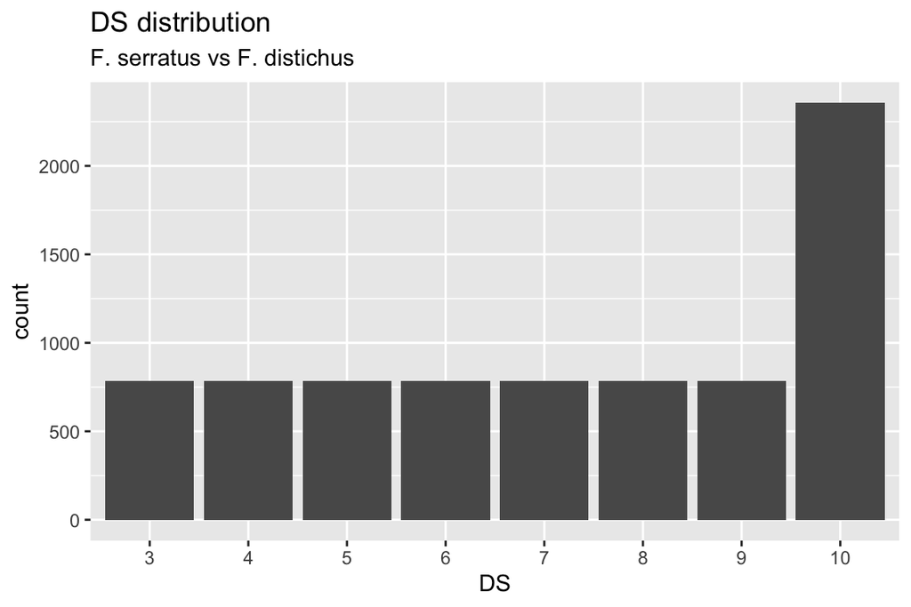

```r
readr::read_csv2("data/Fs_DM.csv") %>%
  ggplot2::ggplot(aes(as.factor(DS))) +
  ggplot2::geom_bar() +
  ggplot2::labs(
    title = "DS distribution",
    subtitle = "F. serratus vs F. distichus",
    x = "DS"
  )
```

However, we cannot use the classic decile approach in *Fucus* (as implemented in orthologr) because more than 10% of the genes have dN of 0 (thus, dNdS of 0). This is because these species are too similar to one another.

This has been solved in the orthologr side.

```r
orthologr::divergence_stratigraphy(..., n_quantile = 8)
```

I shan’t run it here because it is taking too much time.

```r
# orthologr_test_out <-
#   orthologr::divergence_stratigraphy(
#   query_file = "/Users/sodai/Desktop/Algae/Fucus_transcriptome/data/Gene_info/Fucus_distichus/Fucus_distichus_de-novo-transcriptome.fasta.transdecoder_dir/longest_orfs.cds",
#   subject_file = "/Users/sodai/Desktop/Algae/Fucus_transcriptome/data/Gene_info/Fucus_serratus/Fucus_serratus_de-novo-transcriptome.fasta.transdecoder_dir/longest_orfs.cds",
#   n_quantile = 8)
```

Luckily, I already have pre-computed dNdS between *Fucus* species.

```r
Fd_dNdS <- readr::read_csv2("data/Fd_dNdS.csv") %>%
  drop_na() %>%
  dplyr::mutate(GeneID = str_remove(query_id, '\\.p[0-9].*')) %>%
  dplyr::mutate(dN = as.numeric(dN),
                dS = as.numeric(dS),
                dNdS = as.numeric(dNdS)) %>%
  dplyr::group_by(GeneID) %>%
  dplyr::slice(which.min(dNdS)) %>%
  dplyr::ungroup()
```

```
## ℹ Using "','" as decimal and "'.'" as grouping mark. Use `read_delim()` for more control.
```

```r
Fs_dNdS <- readr::read_csv2("data/Fs_dNdS.csv") %>%
  drop_na() %>%
  dplyr::mutate(GeneID = str_remove(query_id, '\\.p[0-9].*')) %>%
  dplyr::mutate(dN = as.numeric(dN),
                dS = as.numeric(dS),
                dNdS = as.numeric(dNdS)) %>%
  dplyr::group_by(GeneID) %>%
  dplyr::slice(which.min(dNdS)) %>%
  dplyr::ungroup()
```

```
## ℹ Using "','" as decimal and "'.'" as grouping mark. Use `read_delim()` for more control.
```

```r
Ec_dNdS <- readr::read_csv2("data/Ec7_Ecs_dNdS.csv") %>%
  drop_na() %>%
  dplyr::mutate(GeneID = query_id) %>%
  # dplyr::mutate(GeneID = str_remove(query_id, '\\.[0-9].*')) %>%
  dplyr::mutate(dN = as.numeric(dN),
                dS = as.numeric(dS),
                dNdS = as.numeric(dNdS)) %>%
  # dplyr::group_by(GeneID) %>%
  # dplyr::slice(which.min(dNdS)) %>%
  dplyr::ungroup()
```

```
## ℹ Using "','" as decimal and "'.'" as grouping mark. Use `read_delim()` for more control.
```

```r
stats::quantile(Fd_dNdS$dNdS,
                probs = seq(0.0, 1, 0.1),
                na.rm = TRUE)
```

```
##       0%      10%      20%      30%      40%      50%      60%      70%
##  0.00000  0.00000  0.12158  0.20330  0.27746  0.37055  0.44264  0.51963
##      80%      90%     100%
##  0.67544  0.99691 10.09000
```

```r
stats::quantile(Fs_dNdS$dN,
                probs = seq(0.0, 1, 0.1),
                na.rm = TRUE)
```

```
##        0%       10%       20%       30%       40%       50%       60%       70%
## 0.0000000 0.0000000 0.0028616 0.0045727 0.0071244 0.0099470 0.0146360 0.0229360
##       80%       90%      100%
## 0.0492240 0.1600100 1.3610000
```

```r
stats::quantile(Ec_dNdS$dN,
                probs = seq(0.0, 1, 0.1),
                na.rm = TRUE)
```

```
##       0%      10%      20%      30%      40%      50%      60%      70%
## 0.000000 0.010190 0.016360 0.022174 0.027970 0.034110 0.041068 0.049486
##      80%      90%     100%
## 0.062388 0.091984 0.739600
```

We drop genes with more than dNdS of 2.

```r
Fs_dNdS_temp <-
  filter(Fs_dNdS, dNdS <= 2) %>% drop_na() # we keep 5,402 genes (prev. 5,554)
Fd_dNdS_temp <-
  filter(Fd_dNdS, dNdS <= 2) %>% drop_na() # we keep 5,363 genes (prev. 5,510).
Ec_dNdS_temp <-
  filter(Ec_dNdS, dNdS <= 2) %>% drop_na() # we keep 10,313 genes (prev. 10,317).

Fs_dNdS_quival <-
  stats::quantile(
    Fs_dNdS_temp[ , "dNdS"],
    probs = seq(0.0, 1, 0.2),
    na.rm = TRUE)
Fd_dNdS_quival <-
  stats::quantile(
    Fd_dNdS_temp[ , "dNdS"],
    probs = seq(0.0, 1, 0.2),
    na.rm = TRUE)
Ec_dNdS_decval <-
  stats::quantile(
    Ec_dNdS_temp[ , "dNdS"],
    probs = seq(0.0, 1, 0.1),
    na.rm = TRUE)

Fs_dNdS_quintiles <- cut(Fs_dNdS_temp$dNdS, breaks = Fs_dNdS_quival, include.lowest = TRUE, labels = FALSE)
Fs_dNdS_temp$DS <- Fs_dNdS_quintiles
Fs_quintiles <- Fs_dNdS_temp %>% select(DS, GeneID)

Fd_dNdS_quintiles <- cut(Fd_dNdS_temp$dNdS, breaks = Fd_dNdS_quival, include.lowest = TRUE, labels = FALSE)
Fd_dNdS_temp$DS <- Fd_dNdS_quintiles
Fd_quintiles <- Fd_dNdS_temp %>% select(DS, GeneID)

Ec_dNdS_quintiles <- cut(Ec_dNdS_temp$dNdS, breaks = Ec_dNdS_decval, include.lowest = TRUE, labels = FALSE)
Ec_dNdS_temp$DS <- Ec_dNdS_quintiles
Ec_deciles <- Ec_dNdS_temp %>% select(DS, GeneID)

rm(Fs_dNdS_temp)
rm(Fd_dNdS_temp)
rm(Ec_dNdS_temp)

Fs_quantiles <- Fs_quintiles
Fd_quantiles <- Fd_quintiles
Ec_quantiles <- Ec_deciles
```

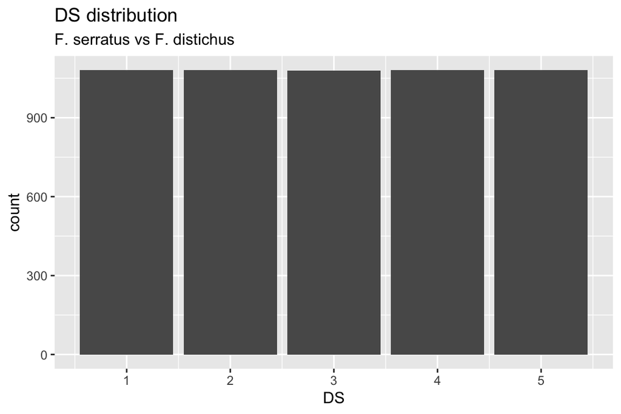

```r
Fs_quantiles %>%
  ggplot2::ggplot(aes(DS)) +
  ggplot2::geom_bar() +
  ggplot2::labs(
    title = "DS distribution",
    subtitle = "F. serratus vs F. distichus",
    x = "DS"
  )
```

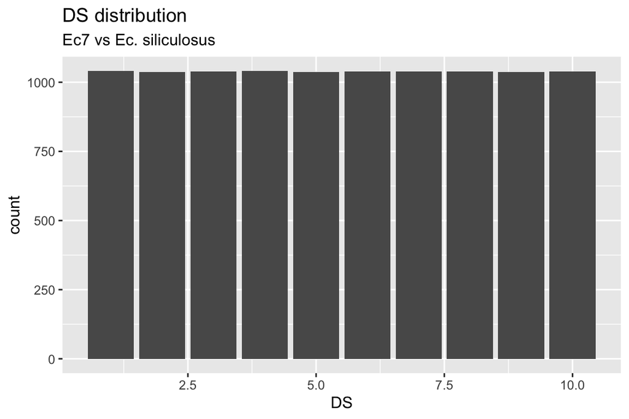

```r
Ec_quantiles %>%
  ggplot2::ggplot(aes(DS)) +
  ggplot2::geom_bar() +
  ggplot2::labs(
    title = "DS distribution",
    subtitle = "Ec7 vs Ec. siliculosus",
    x = "DS"
  )
```

Get the abundance data.

```r
Fd_abundance <-
  readr::read_csv("data/Fd_abundance.csv")
Fs_abundance <-
  readr::read_csv("data/Fs_abundance.csv")
Ec_abundance <-
  readr::read_csv("data/Ec_abundance.csv")
Ec_abundance_25f <-
  Ec_abundance %>%
  dplyr::select(1 | dplyr::starts_with("F_"))
Ec_abundance_32m <-
  Ec_abundance %>%
  dplyr::select(1 | dplyr::starts_with("M_"))
```

Get the sample information.

```r
sample_info_fd <-
  readr::read_csv("data/sample_info_fd.csv")
sample_info_fs <-
  readr::read_csv("data/sample_info_fs.csv")
sample_info_ec <-
  readr::read_csv("data/sample_info_ec.csv")
```

# Construct DES

Function to construct the DivergenceExpressionSet (DES), saving lines.

```r
construct_DES <-
  function(
    ExpressionMatrix,
    DivergenceMap,
    metadata,
    AVG = median,
    grouping_var = "Stage",
    name_var = "LibName",
    transform_opt = F,
    transformation){
  RepCol <-
    metadata %>%
    dplyr::group_by(.data[[grouping_var]]) %>%
    dplyr::summarize(n=dplyr::n()) %>%
    dplyr::arrange(
      base::factor(
        .data[[grouping_var]],
        levels = base::unique(metadata[,grouping_var][[1]])
        )
      ) %>%
    base::as.vector()
  # making sure the metadata and the expression set match
  DES <-
    ExpressionMatrix %>%
    dplyr::left_join(
      dplyr::select(
        DivergenceMap,
        c(GeneID, DS)
        )
      ) %>%
    tidyr::drop_na() %>% # NAs can ruin the transformation.
    dplyr::relocate(DS, GeneID)
  if(transform_opt){
    if(transformation == "rlog"){
      DES <-
        myTAI::tf(
          DES,
          FUN = rlog,
          integerise = TRUE)
    }
    else if(transformation == "vst"){
      DES <-
        myTAI::tf(
          DES,
          FUN = vst,
          integerise = TRUE)
    }
  }
  DES_FILT <-
    DES %>%
    dplyr::select(1:2 | metadata[,name_var][[1]])
  OUT <- DES_FILT %>%
    myTAI::CollapseReplicates(
      RepCol$n,
      AVG,
      stage.names = RepCol[[grouping_var]])
  return(OUT)
}
```

Unlike rank, sqrt and log2 transformations, the rlog and vst transformation looks at the columns. This is why we select columns `dplyr::select(1:2 | metadata[,name_var][[1]])` and collaps replicates `myTAI::CollapseReplicates()` after choosing either of the two transformations. More about transformations in `1.3 Transformations`.

```r
Fd_DES <-
  construct_DES(
    Fd_abundance,
    Fd_quantiles,
    sample_info_fd
  )
Fd_DES_M <-
  construct_DES(
    Fd_abundance,
    Fd_quantiles,
    dplyr::filter(sample_info_fd, Sex == "M")
  )
Fd_DES_F <-
  construct_DES(
    Fd_abundance,
    Fd_quantiles,
    dplyr::filter(sample_info_fd, Sex == "F")
  )
Fs_DES <-
  construct_DES(
    Fs_abundance,
    Fs_quantiles,
    sample_info_fs
  )
Fs_DES_M <-
  construct_DES(
    Fs_abundance,
    Fs_quantiles,
    dplyr::filter(sample_info_fs, Sex == "M")
  )
Fs_DES_F <-
  construct_DES(
    Fs_abundance,
    Fs_quantiles,
    dplyr::filter(sample_info_fs, Sex == "F")
  )
Ec_DES_25f <-
  construct_DES(
    Ec_abundance_25f,
    Ec_quantiles,
    dplyr::filter(
      sample_info_ec,
      Sex == "F"),
    name_var = "SampleName"
    )
Ec_DES_32m <-
  construct_DES(
    Ec_abundance_32m,
    Ec_quantiles,
    dplyr::filter(
      sample_info_ec,
      Sex == "M"),
    name_var = "SampleName"
    )
```

We further look into the DES of *all* *Fucus* tissues in the matSP.

```r
Fd_DES_matSP <-
  construct_DES(
    Fd_abundance,
    Fd_quantiles,
    dplyr::filter(
      sample_info_fd,
      Stage == "matSP"),
    grouping_var = "Tissue"
  )
Fs_DES_F_matSP <-
  construct_DES(
    Fs_abundance,
    Fs_quantiles,
    dplyr::filter(
      sample_info_fs,
      Stage == "matSP" & Sex == "F"),
    grouping_var = "Tissue"
  )
Fs_DES_M_matSP <-
  construct_DES(
    Fs_abundance,
    Fs_quantiles,
    dplyr::filter(
      sample_info_fs,
      Stage == "matSP" & Sex == "M"),
    grouping_var = "Tissue"
  )
```

rlog transformations of all the datasets.

```r
Fd_DES.rlog <-
  construct_DES(
    Fd_abundance,
    Fd_quantiles,
    sample_info_fd,
    transform_opt = T,
    transformation = "rlog"
  )
```

```
## rlog() may take a few minutes with 30 or more samples, vst() is a much faster
## transformation
```

```r
Fd_DES_M.rlog <-
  construct_DES(
    Fd_abundance,
    Fd_quantiles,
    dplyr::filter(sample_info_fd, Sex == "M"),
    transform_opt = T,
    transformation = "rlog"
  )
```

```
## rlog() may take a few minutes with 30 or more samples, vst() is a much faster
## transformation
```

```r
Fd_DES_F.rlog <-
  construct_DES(
    Fd_abundance,
    Fd_quantiles,
    dplyr::filter(sample_info_fd, Sex == "F"),
    transform_opt = T,
    transformation = "rlog"
  )
```

```
## rlog() may take a few minutes with 30 or more samples, vst() is a much faster
## transformation
```

```r
Fs_DES.rlog <-
  construct_DES(
    Fs_abundance,
    Fs_quantiles,
    sample_info_fs,
    transform_opt = T,
    transformation = "rlog"
  )
```

```
## rlog() may take a few minutes with 30 or more samples, vst() is a much faster
## transformation
```

```r
Fs_DES_M.rlog <-
  construct_DES(
    Fs_abundance,
    Fs_quantiles,
    dplyr::filter(sample_info_fs, Sex == "M"),
    transform_opt = T,
    transformation = "rlog"
  )
```

```
## rlog() may take a few minutes with 30 or more samples, vst() is a much faster
## transformation
```

```r
Fs_DES_F.rlog <-
  construct_DES(
    Fs_abundance,
    Fs_quantiles,
    dplyr::filter(sample_info_fs, Sex == "F"),
    transform_opt = T,
    transformation = "rlog"
  )
```

```
## rlog() may take a few minutes with 30 or more samples, vst() is a much faster
## transformation
```

```r
Ec_DES_25f.rlog <-
  construct_DES(
    Ec_abundance_25f,
    Ec_quantiles,
    dplyr::filter(
      sample_info_ec,
      Sex == "F"),
    name_var = "SampleName",
    transform_opt = T,
    transformation = "rlog"
    )
Ec_DES_32m.rlog <-
  construct_DES(
    Ec_abundance_32m,
    Ec_quantiles,
    dplyr::filter(
      sample_info_ec,
      Sex == "M"),
    name_var = "SampleName",
    transform_opt = T,
    transformation = "rlog"
    )
Fd_DES_matSP.rlog <-
  construct_DES(
    Fd_abundance,
    Fd_quantiles,
    dplyr::filter(
      sample_info_fd,
      Stage == "matSP"),
    grouping_var = "Tissue",
    transform_opt = T,
    transformation = "rlog"
  )
```

```
## rlog() may take a few minutes with 30 or more samples, vst() is a much faster
## transformation
```

```r
Fs_DES_F_matSP.rlog <-
  construct_DES(
    Fs_abundance,
    Fs_quantiles,
    dplyr::filter(
      sample_info_fs,
      Stage == "matSP" & Sex == "F"),
    grouping_var = "Tissue",
    transform_opt = T,
    transformation = "rlog"
  )
```

```
## rlog() may take a few minutes with 30 or more samples, vst() is a much faster
## transformation
```

```r
Fs_DES_M_matSP.rlog <-
  construct_DES(
    Fs_abundance,
    Fs_quantiles,
    dplyr::filter(
      sample_info_fs,
      Stage == "matSP" & Sex == "M"),
    grouping_var = "Tissue",
    transform_opt = T,
    transformation = "rlog"
  )
```

```
## rlog() may take a few minutes with 30 or more samples, vst() is a much faster
## transformation
```

# denoised data

```r
Fd_abundance.denoised <-
  readr::read_csv("data/Fd_abundance_denoised.csv")
Fs_abundance.denoised <-
  readr::read_csv("data/Fs_abundance_denoised.csv")
Ec_abundance.denoised <-
  readr::read_csv("data/Ec_abundance_denoised.csv")
Ec_abundance.denoised_25f <-
  Ec_abundance.denoised %>%
  dplyr::select(1 | dplyr::starts_with("F_"))
Ec_abundance.denoised_32m <-
  Ec_abundance.denoised %>%
  dplyr::select(1 | dplyr::starts_with("M_"))
```

Developmental stages

```r
Fd_DES.denoised <-
  construct_DES(
    Fd_abundance.denoised,
    Fd_quantiles,
    sample_info_fd
  )
Fd_DES_M.denoised <-
  construct_DES(
    Fd_abundance.denoised,
    Fd_quantiles,
    dplyr::filter(sample_info_fd, Sex == "M")
  )
Fd_DES_F.denoised <-
  construct_DES(
    Fd_abundance.denoised,
    Fd_quantiles,
    dplyr::filter(sample_info_fd, Sex == "F")
  )
Fs_DES.denoised <-
  construct_DES(
    Fs_abundance.denoised,
    Fs_quantiles,
    sample_info_fs
  )
Fs_DES_M.denoised <-
  construct_DES(
    Fs_abundance.denoised,
    Fs_quantiles,
    dplyr::filter(sample_info_fs, Sex == "M")
  )
Fs_DES_F.denoised <-
  construct_DES(
    Fs_abundance.denoised,
    Fs_quantiles,
    dplyr::filter(sample_info_fs, Sex == "F")
  )
Ec_DES_25f.denoised <-
  construct_DES(
    Ec_abundance.denoised_25f,
    Ec_quantiles,
    dplyr::filter(
      sample_info_ec,
      Sex == "F"),
    name_var = "SampleName"
    )
Ec_DES_32m.denoised <-
  construct_DES(
    Ec_abundance.denoised_32m,
    Ec_quantiles,
    dplyr::filter(
      sample_info_ec,
      Sex == "M"),
    name_var = "SampleName"
    )
```

Tissues

```r
Fd_DES_matSP.denoised <-
  construct_DES(
    Fd_abundance.denoised,
    Fd_quantiles,
    dplyr::filter(
      sample_info_fd,
      Stage == "matSP"),
    grouping_var = "Tissue"
  )
Fs_DES_F_matSP.denoised <-
  construct_DES(
    Fs_abundance.denoised,
    Fs_quantiles,
    dplyr::filter(
      sample_info_fs,
      Stage == "matSP" & Sex == "F"),
    grouping_var = "Tissue"
  )
Fs_DES_M_matSP.denoised <-
  construct_DES(
    Fs_abundance.denoised,
    Fs_quantiles,
    dplyr::filter(
      sample_info_fs,
      Stage == "matSP" & Sex == "M"),
    grouping_var = "Tissue"
  )
```

In the denoised dataset, it makes little sense to apply the r-log transformation.

# Save DES

```r
Fd_DES %>%
  readr::write_csv(file = "data/Fd_DES.csv")
Fd_DES_F %>%
  readr::write_csv(file = "data/Fd_DES_F.csv")
Fd_DES_M %>%
  readr::write_csv(file = "data/Fd_DES_M.csv")
Fs_DES %>%
  readr::write_csv(file = "data/Fs_DES.csv")
Fs_DES_F %>%
  readr::write_csv(file = "data/Fs_DES_F.csv")
Fs_DES_M %>%
  readr::write_csv(file = "data/Fs_DES_M.csv")
Ec_DES_32m %>%
  readr::write_csv(file = "data/Ec_DES_32m.csv")
Ec_DES_25f %>%
  readr::write_csv(file = "data/Ec_DES_25f.csv")

Fd_DES_matSP %>%
  readr::write_csv(file = "data/Fd_DES_matSP.csv")
Fs_DES_M_matSP %>%
  readr::write_csv(file = "data/Fs_DES_M_matSP.csv")
Fs_DES_F_matSP %>%
  readr::write_csv(file = "data/Fs_DES_F_matSP.csv")

## and the rlog transformed abundances

Fd_DES.rlog %>%
  readr::write_csv(file = "data/Fd_DES.rlog.csv")
Fd_DES_F.rlog %>%
  readr::write_csv(file = "data/Fd_DES_F.rlog.csv")
Fd_DES_M.rlog %>%
  readr::write_csv(file = "data/Fd_DES_M.rlog.csv")
Fs_DES.rlog %>%
  readr::write_csv(file = "data/Fs_DES.rlog.csv")
Fs_DES_F.rlog %>%
  readr::write_csv(file = "data/Fs_DES_F.rlog.csv")
Fs_DES_M.rlog %>%
  readr::write_csv(file = "data/Fs_DES_M.rlog.csv")
Ec_DES_32m.rlog %>%
  readr::write_csv(file = "data/Ec_DES_32m.rlog.csv")
Ec_DES_25f.rlog %>%
  readr::write_csv(file = "data/Ec_DES_25f.rlog.csv")

Fd_DES_matSP.rlog %>%
  readr::write_csv(file = "data/Fd_DES_matSP.rlog.csv")
Fs_DES_M_matSP.rlog %>%
  readr::write_csv(file = "data/Fs_DES_M_matSP.rlog.csv")
Fs_DES_F_matSP.rlog %>%
  readr::write_csv(file = "data/Fs_DES_F_matSP.rlog.csv")

## and the denoised data

Fd_DES.denoised %>%
  readr::write_csv(file = "data/Fd_DES_denoised.csv")
Fd_DES_F.denoised %>%
  readr::write_csv(file = "data/Fd_DES_F_denoised.csv")
Fd_DES_M.denoised %>%
  readr::write_csv(file = "data/Fd_DES_M_denoised.csv")
Fs_DES.denoised %>%
  readr::write_csv(file = "data/Fs_DES_denoised.csv")
Fs_DES_F.denoised %>%
  readr::write_csv(file = "data/Fs_DES_F_denoised.csv")
Fs_DES_M.denoised %>%
  readr::write_csv(file = "data/Fs_DES_M_denoised.csv")
Ec_DES_32m.denoised %>%
  readr::write_csv(file = "data/Ec_DES_32m_denoised.csv")
Ec_DES_25f.denoised %>%
  readr::write_csv(file = "data/Ec_DES_25f_denoised.csv")

Fd_DES_matSP.denoised %>%
  readr::write_csv(file = "data/Fd_DES_matSP_denoised.csv")
Fs_DES_M_matSP.denoised %>%
  readr::write_csv(file = "data/Fs_DES_M_matSP_denoised.csv")
Fs_DES_F_matSP.denoised %>%
  readr::write_csv(file = "data/Fs_DES_F_matSP_denoised.csv")
```

Also, save the gene-wise divergence-strata.

```r
Fd_quantiles %>%
  readr::write_csv(file = "data/Fd_Fs_DM_5.csv")
Fs_quantiles %>%
  readr::write_csv(file = "data/Fs_Fd_DM_5.csv")
Ec_quantiles %>%
  readr::write_csv(file = "data/Ec_Es_DM_10.csv")
```

# Visualise dNdS & gene age correspondence

```r
library(scales)
library(see)
Ec_age <- readr::read_csv("data/Ec_age_processed.csv")
Fd_age <- readr::read_csv("data/Fd_age_processed.csv")
Fs_age <- readr::read_csv("data/Fs_age_processed.csv")
```

## For *Fucus*

```r
Kendall_dNdS <- Fd_dNdS %>%
  filter(dNdS < 2, !dNdS == 0) %>%
  left_join(Fd_age)
```

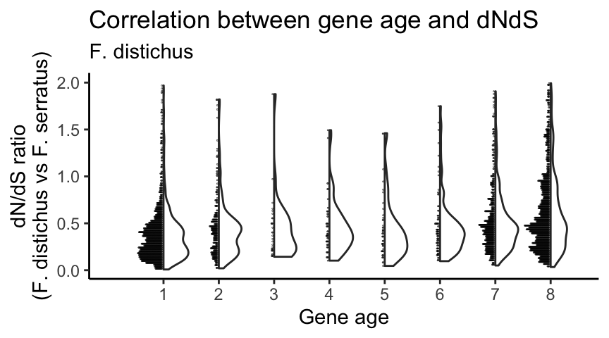

```r
Kendall_dNdS %>% drop_na() %>%
  ggplot(aes(x = rank, y = dNdS, group = rank)) +
  see::geom_violindot(dots_size = 0.2, binwidth = 0.02) +
  labs(title = "Correlation between gene age and dNdS",
       subtitle = "F. distichus",
       x = "Gene age",
       y = "dN/dS ratio\n(F. distichus vs F. serratus)") +
  scale_x_continuous(breaks=c(1:max(Kendall_dNdS$rank, na.rm = TRUE))) +
  theme_classic()
```

```r
res<-cor.test(Kendall_dNdS$rank,Kendall_dNdS$dNdS, method="kendall")
res
```

```
##
##  Kendall's rank correlation tau
##
## data:  Kendall_dNdS$rank and Kendall_dNdS$dNdS
## z = 19.38, p-value < 2.2e-16
## alternative hypothesis: true tau is not equal to 0
## sample estimates:
##       tau
## 0.2158503
```

```r
Kendall_dNdS <- Fs_dNdS %>%
  filter(dNdS < 2, !dNdS == 0) %>%
  left_join(Fs_age)
```

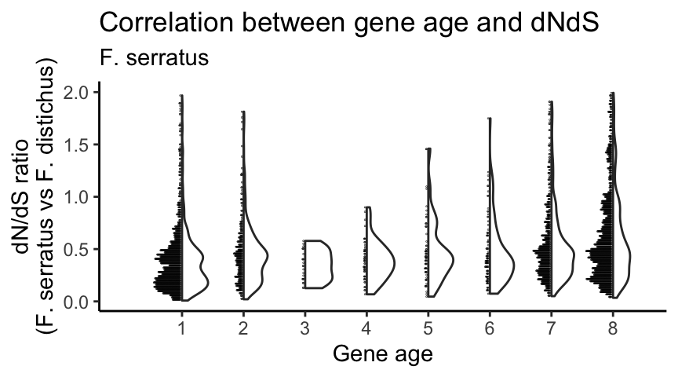

```r
Kendall_dNdS %>% drop_na() %>%
  ggplot(aes(x = rank, y = dNdS, group = rank)) +
  see::geom_violindot(dots_size = 0.2, binwidth = 0.02) +
  labs(title = "Correlation between gene age and dNdS",
       subtitle = "F. serratus",
       x = "Gene age",
       y = "dN/dS ratio\n(F. serratus vs F. distichus)") +
  scale_x_continuous(breaks=c(1:max(Kendall_dNdS$rank, na.rm = TRUE))) +
  theme_classic()
```

```r
res<-cor.test(Kendall_dNdS$rank,Kendall_dNdS$dNdS, method="kendall")
res
```

```
##
##  Kendall's rank correlation tau
##
## data:  Kendall_dNdS$rank and Kendall_dNdS$dNdS
## z = 18.228, p-value < 2.2e-16
## alternative hypothesis: true tau is not equal to 0
## sample estimates:
##       tau
## 0.2021548
```

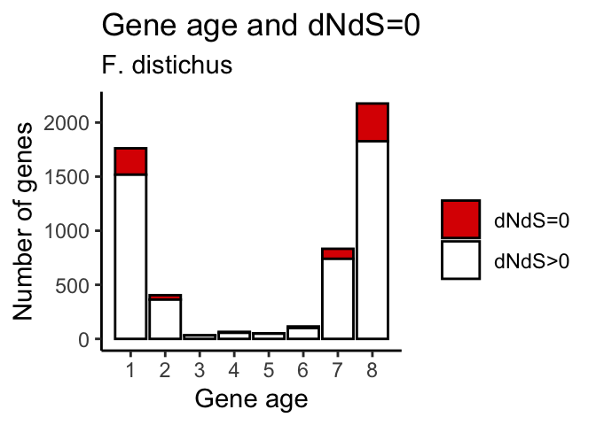

```r
# Kendall_dNdS <- Fd_dNdS %>%
#   filter(dNdS == 0) %>%
#   left_join(Fd_age)
# Kendall_dNdS %>% drop_na() %>%
#   ggplot(aes(x = rank)) +
#   ggplot2::geom_bar() +
#   labs(title = "Gene age and dNdS=0",
#        subtitle = "F. distichus",
#        x = "Gene age",
#        y = "Genes where dNdS=0 \n(F. distichus vs F. serratus)") +
#   scale_x_continuous(breaks=c(1,2,3,4,5,6,7,8)) +
#   theme_classic()

Kendall_dNdS <- Fd_dNdS %>%
  mutate(zero = case_when(
    dNdS == 0 ~ "dNdS=0",
    TRUE ~ "dNdS>0")) %>%
  left_join(Fd_age)
Kendall_dNdS %>% drop_na() %>%
  ggplot(aes(x = rank, fill = zero)) +
  ggplot2::geom_bar(colour = "black") +
  labs(title = "Gene age and dNdS=0",
       subtitle = "F. distichus",
       x = "Gene age",
       y = "Number of genes",
       fill = "") +
  scale_x_continuous(breaks=c(1:max(Kendall_dNdS$rank, na.rm = TRUE))) +
  theme_classic() +
  scale_fill_manual(values = c("#DC0000FF", "white"))
```

```r
Kendall_dNdS <- Fs_dNdS %>%
  mutate(zero = case_when(
    dNdS == 0 ~ "dNdS=0",
    TRUE ~ "dNdS>0")) %>%
  left_join(Fs_age)
```

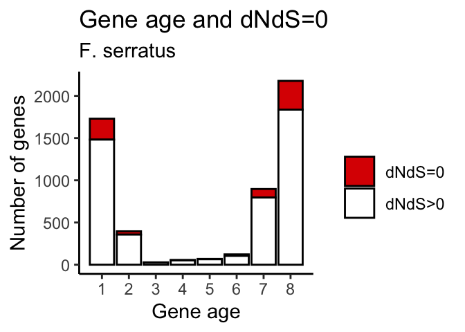

```r
Kendall_dNdS %>% drop_na() %>%
  ggplot(aes(x = rank, fill = zero)) +
  ggplot2::geom_bar(colour = "black") +
  labs(title = "Gene age and dNdS=0",
       subtitle = "F. serratus",
       x = "Gene age",
       y = "Number of genes",
       fill = "") +
  scale_x_continuous(breaks=c(1:max(Kendall_dNdS$rank, na.rm = TRUE))) +
  theme_classic() +
  scale_fill_manual(values = c("#DC0000FF", "white"))
```

## For *Ectocaprus*

```r
Kendall_dNdS <- Ec_dNdS %>%
  filter(dNdS < 2, !dNdS == 0) %>%
  left_join(Ec_age)
```

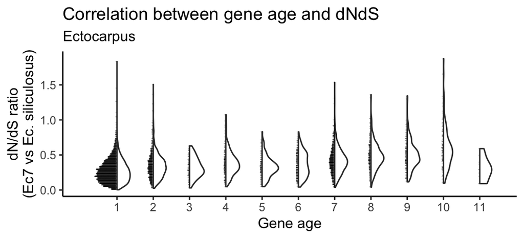

```r
Kendall_dNdS %>% drop_na() %>%
  ggplot(aes(x = rank, y = dNdS, group = rank)) +
  see::geom_violindot(dots_size = 0.05, binwidth = 0.02) +
  labs(title = "Correlation between gene age and dNdS",
       subtitle = "Ectocarpus",
       x = "Gene age",
       y = "dN/dS ratio\n(Ec7 vs Ec. siliculosus)") +
  scale_x_continuous(breaks=c(1:max(Kendall_dNdS$rank, na.rm = TRUE))) +
  theme_classic()
```

```r
res<-cor.test(Kendall_dNdS$rank,Kendall_dNdS$dNdS, method="kendall")
res
```

```
##
##  Kendall's rank correlation tau
##
## data:  Kendall_dNdS$rank and Kendall_dNdS$dNdS
## z = 37.101, p-value < 2.2e-16
## alternative hypothesis: true tau is not equal to 0
## sample estimates:
##       tau
## 0.2880629
```

```r
Kendall_dNdS <- Ec_dNdS %>%
  mutate(zero = case_when(
    dNdS == 0 ~ "dNdS=0",
    TRUE ~ "dNdS>0")) %>%
  left_join(Ec_age)
```

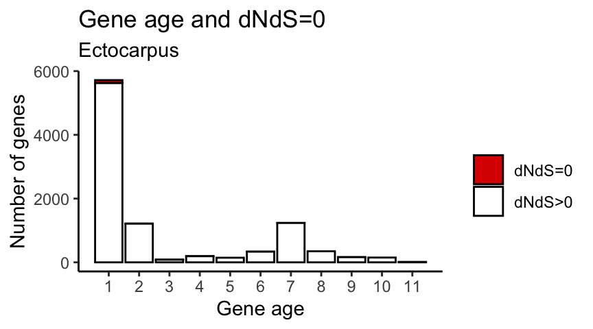

```r
Kendall_dNdS %>% drop_na() %>%
  ggplot(aes(x = rank, fill = zero)) +
  ggplot2::geom_bar(colour = "black") +
  labs(title = "Gene age and dNdS=0",
       subtitle = "Ectocarpus",
       x = "Gene age",
       y = "Number of genes",
       fill = "") +
  scale_x_continuous(breaks=c(1:max(Kendall_dNdS$rank, na.rm = TRUE))) +
  theme_classic() +
  scale_fill_manual(values = c("#DC0000FF", "white"))
```